# Estimador Intervalar

Alex Gama

12/04/2022

# 1 Objetivo

O objetivo deste relátorio é descrever sobre o teste de hipótese homocedastidade, simular e apresentar os cálculos analíticos de uma distribuição pelo metodo da quantidade pivotal e aplicar o intervalo de confiança.

# 2 Introdução

Quando a variância populacional ($\sigma^2$) é desconhecida, o intervalo de confiança para a média é construído usando a **distribuição $t$-Student**.

## 2.1 Fórmula do Intervalo de Confiança

$$IC = \left[ \bar{x} - t_{\alpha/2, n-1} \cdot \frac{s}{\sqrt{n}}, \, \bar{x} + t_{\alpha/2, n-1} \cdot \frac{s}{\sqrt{n}} \right]$$

Onde: - $\bar{x}$: média amostral. - $s$: desvio padrão amostral. - $n$: tamanho da amostra. - $t_{\alpha/2, n-1}$: valor crítico da distribuição $t$-Student com $n-1$ graus de liberdade. - $1-\alpha$: nível de confiança.

## 2.2 Quando Usar?

1. A população segue uma **distribuição normal** ou $n \geq 30$ (pelo Teorema Central do Limite).
2. A variância populacional ($\sigma^2$) é **desconhecida**, sendo substituída pelo desvio padrão amostral ($s$).

## 2.3 Exemplo Prático

Vamos calcular o intervalo de confiança para os seguintes dados:

- Média amostral ($\bar{x}$) = 50.
- Desvio padrão amostral ($s$) = 10.
- Tamanho da amostra ($n$) = 25.
- Nível de confiança ($1-\alpha$) = 95%.

### 2.3.1 Código gerador em R

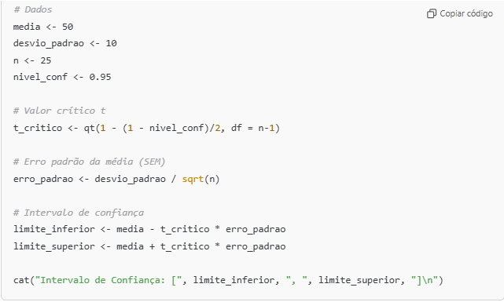

### 2.3.2 Resultado apresentado

[figure not shown]

# 3 Homocedastidade

A homocedasticidade demanda que as variações em torno da linha de regressão sejam constantes para todos os valores de X. Isto expressa que Y varia na mesma proporção, quando X for um valor baixo e quando X for um valor elevado. O contrário desse fenômeno é conhecido por heterocedasticidade, ou seja, a variância não será constante para os valores X e Y.

## 3.1 Diferenças entre Homocedasticidade e Heterocedasticidade

**Homocedasticidade**

A variância dos erros é constante para todos os valores das variáveis independentes. É uma suposição fundamental em muitos modelos estatísticos, como a regressão linear clássica. Visualmente, ao plotar os resíduos contra os valores preditos, eles aparecem distribuídos de maneira uniforme, sem padrão aparente.

**Heterocedasticidade**

A variância dos erros muda dependendo do valor das variáveis independentes. Ou seja, os erros não têm uma dispersão uniforme. Indica problemas no modelo que podem afetar as inferências estatísticas, como p-valores e intervalos de confiança. Visualmente, ao plotar os resíduos contra os valores preditos, você verá um padrão, como um funil (a variância aumenta ou diminui sistematicamente).

## 3.2 Quadro comparativo

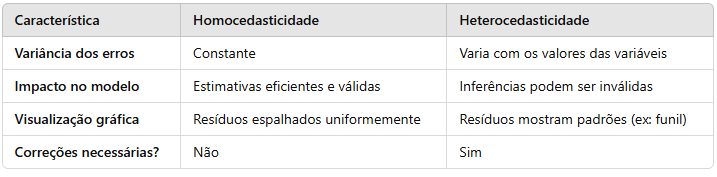

# 4 Distribuição da Quantidade Pivotal(Q.P)

Neste relatório, demonstramos a distribuição da quantidade pivotal de forma **analítica** e **gráfica**. Consideramos uma variável aleatória $X$ com distribuição normal $N(\mu, \sigma^2)$, para a qual a quantidade pivotal é dada por:

$$Z = \frac{\bar{X} - \mu}{\sigma / \sqrt{n}}$$

onde $Z$ segue uma distribuição normal padrão $N(0, 1)$.

## 4.1 Código gerador em R

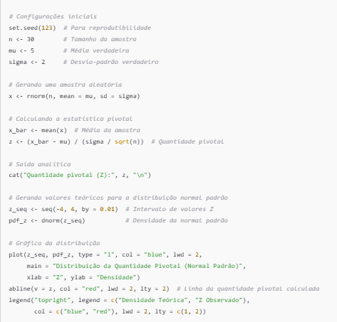

## 4.2 Resultado apresentado

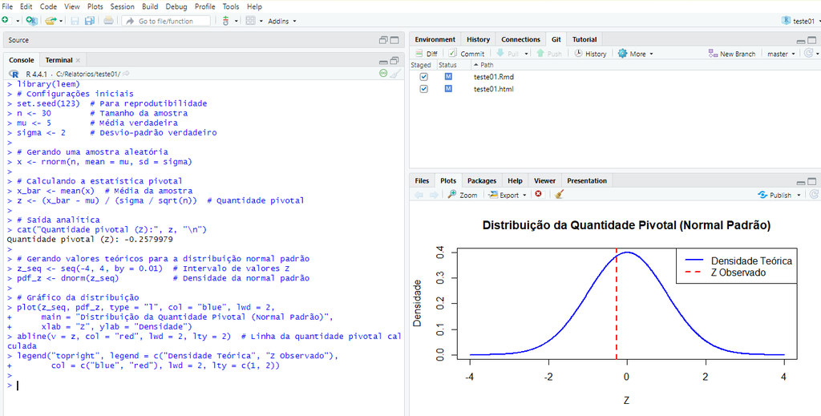

# 5 Apresentação da aplicação do Intervalo de Confiança(I.C) em conjunto de dados

**Problema proposto**

Para avaliar a qualidade dos rolamentos produzidos,um engenheiro recolheu uma amostras aleatória de 12 esferas da produção diária.Usando um paquímetro ele obteve as seguintes medições 8,2 - 8,3 - 8,4 - 8,2 - 8,2 8,4 - 8,3 - 8,2 - 8,4 - 8,4 - 8,2 - 8,4 para as esferas. Calcule o intervalo de confiança para a média das esferas produzidas com 95% de confiança.

## 5.1 Dados Fornecidos do problema

Medições da amostra:
$$\{8.2, 8.3, 8.4, 8.2, 8.2, 8.4, 8.3, 8.2, 8.4, 8.4, 8.2, 8.4\}$$
Tamanho da amostra ($n$): 12
Nível de confiança: $95\%$

## 5.2 Cálculos

### 5.2.1 Cálculo da Média ($\bar{x}$)

A fórmula da média é:
$$\bar{x} = \frac{\text{soma dos dados}}{n}$$
Substituindo os valores:
$$\bar{x} = \frac{8.2 + 8.3 + 8.4 + 8.2 + 8.2 + 8.4 + 8.3 + 8.2 + 8.4 + 8.4 + 8.2 + 8.4}{12}$$
$$\bar{x} = \frac{99.6}{12} = 8.3$$

### 5.2.2 Cálculo do Desvio Padrão Amostral ($s$)

A fórmula do desvio padrão amostral é:
$$s = \sqrt{\frac{\sum (x_i - \bar{x})^2}{n-1}}$$

**Diferenças dos quadrados**

Para cada dado ($x_i$), calculamos $(x_i - \bar{x})^2$:
$$\begin{aligned}
(8.2 - 8.3)^2 & = 0.01, \\
(8.3 - 8.3)^2 & = 0.00, \\
(8.4 - 8.3)^2 & = 0.01, \\
(8.2 - 8.3)^2 & = 0.01, \\
(8.2 - 8.3)^2 & = 0.01, \\
(8.4 - 8.3)^2 & = 0.01, \\
(8.3 - 8.3)^2 & = 0.00, \\
(8.2 - 8.3)^2 & = 0.01, \\
(8.4 - 8.3)^2 & = 0.01, \\
(8.4 - 8.3)^2 & = 0.01, \\
(8.2 - 8.3)^2 & = 0.01, \\
(8.4 - 8.3)^2 & = 0.01.
\end{aligned}$$

**Soma das diferenças dos quadrados**

$$\sum (x_i - \bar{x})^2 = 0.01 + 0.00 + 0.01 + 0.01 + 0.01 + 0.01 + 0.00 + 0.01 + 0.01 + 0.01 + 0.01 + 0.01 = 0.1$$

### 5.2.3 Valor Crítico ($t^*$)

Para um nível de confiança de $95\%$ e $n-1 = 11$ graus de liberdade, o valor crítico $t^*$ obtido da tabela $t$-Student é:
$$t^* \approx 2.201$$

## 5.4 Simulação em R

[figure not shown]